# Salton Sea shoreline sediment sampling locations

# Background

Several species of shorebirds were recently found to consume significant amounts of biofilm, a previously unknown food source, on intertidal mudflats. The Salton Sea, an inland saline lake, is the largest body of water in California and an essential stopover habitat for migrating shorebirds on the Pacific Flyway. In 2023, I sampled sediments from the Sea’s shoreline mudflats to determine if biofilm is present and contributing to the diets of migrating shorebirds. These points represent locations sampled during spring, summer, and fall.

# Data

I collected these points in April, July, and October of 2023 on the eastern shore of the Salton Sea. To show the three separate visits to the Bombay Beach area, I subsetted those into a second df.

```r
require(tidyverse)
require(sf)
require(tigris)
require(geodata)
require(terra)
require(colorspace)
require(tidyterra)
require(ggnewscale)
require(tmap)
require(RColorBrewer)
siteData <- read.csv('https://raw.githubusercontent.com/togepi99/SpatialEcology/main/Week%202/output.csv')
siteData$Month <- format(as.Date(siteData$Timestamp), "%m-%Y")
bombayBeach <- subset(subset(siteData, Lat>33.3), Lat<33.4)
```

I created bounding boxes around the two sets of points.

```r
siteSf <- st_as_sf(siteData, coords=c('Lon', 'Lat'), crs='+proj=longlat +ellips=WGS84')

studyArea <- st_bbox(siteSf)
studyArea <- studyArea + c(-0.13, -0.06, 0.05, 0.05)
studyArea <- st_as_sfc(studyArea)

bbSf <- st_as_sf(bombayBeach, coords=c('Lon', 'Lat'), crs='+proj=longlat +ellips=WGS84')

bbArea <- st_bbox(bbSf) + c(-0.005, -0.005, 0.005, 0.005)
bbArea <- st_as_sfc(bbArea)

bbAreaBig <- st_bbox(bbSf) + c(-0.02, -0.02, 0.02, 0.02)
bbAreaBig <- st_as_sfc(bbAreaBig)
```

I want to show the Salton Sea’s location in the state of California and show that it is California’s largest lake. I downloaded the state shape file from tigris. I dowloaded a raster from geodata showing water landcover for the USA and used the shape file to crop and mask it.

```r
california <- states() %>%
  filter(NAME=='California')
```

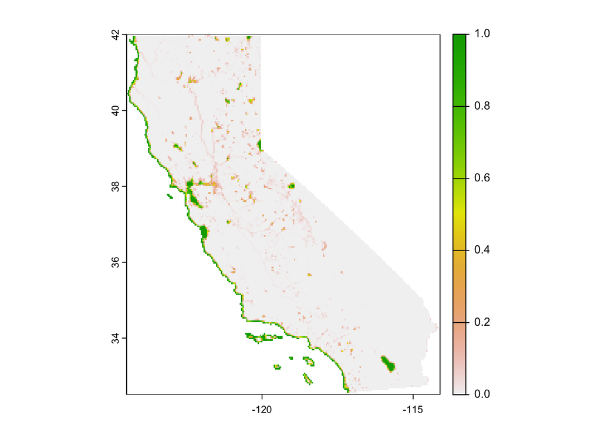

```r
california <- st_transform(california, st_crs(siteSf))
st_crs(california)$proj4string

usaWater <- landcover(var='water', country='USA', path=tempdir())

californiaWater <- crop(usaWater, california)
californiaWater <- mask(californiaWater, california)
californiaWater <- aggregate(californiaWater, fact=5, fun="mean")

plot(californiaWater)
```

The rasters from geodata did not have a high enough resolution to show landscape details around the Salton Sea. I requested a higher-resolution landcover raster from MRLC.

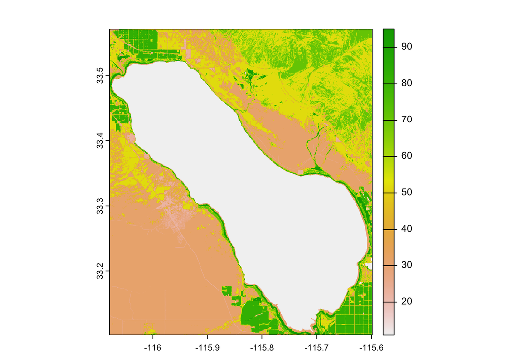

```r
raster <- rast('https://github.com/togepi99/SpatialEcology/raw/main/Week%202/NLCD_lCk6kYi4aKwW4nTdBDKJ/NLCD_2021_Land_Cover_L48_20230630_lCk6kYi4aKwW4nTdBDKJ.tiff')
raster[is.na(raster)] = 0
raster <- project(raster, crs(bbSf, proj=T))
rasterSa <- crop(raster, studyArea)
rasterBb <- crop(raster, bbArea)

rasterSa <- aggregate(rasterSa, fact=2, fun="mean")
plot(rasterSa)
```

Plot 1 shows the location of the Salton Sea in California.

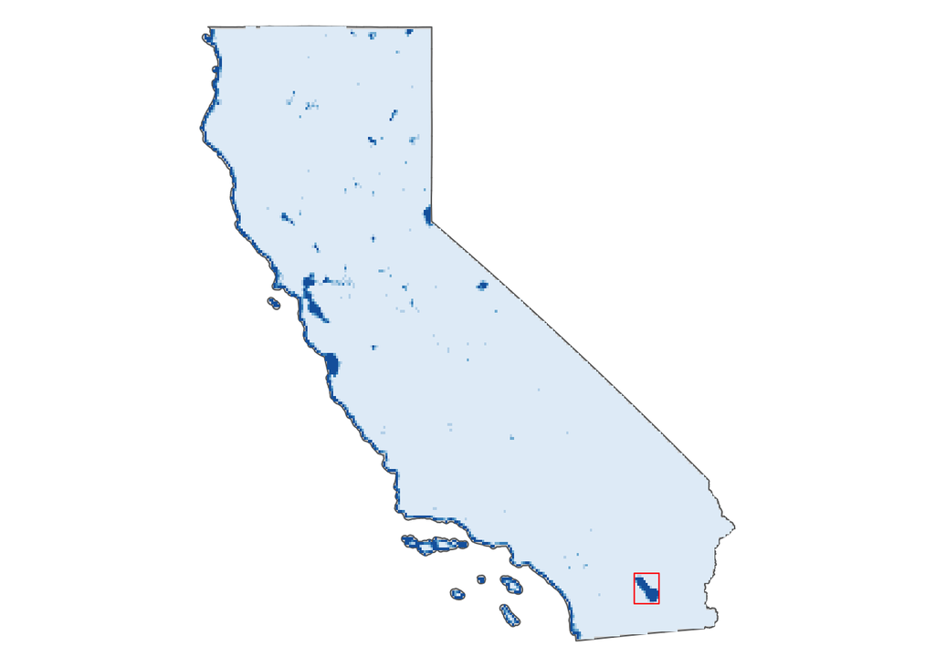

```r
tmap_options(max.categories = 256)

Cali <- tm_shape(california)+
  tm_polygons()+
  tm_shape(californiaWater)+
  tm_raster(palette = "Blues", legend.show = FALSE)+
  tm_shape(studyArea)+
  tm_borders(col = 'red')+
  tm_layout(frame = FALSE)

Cali
```

Plot 2 shows the sampling areas around the Sea.

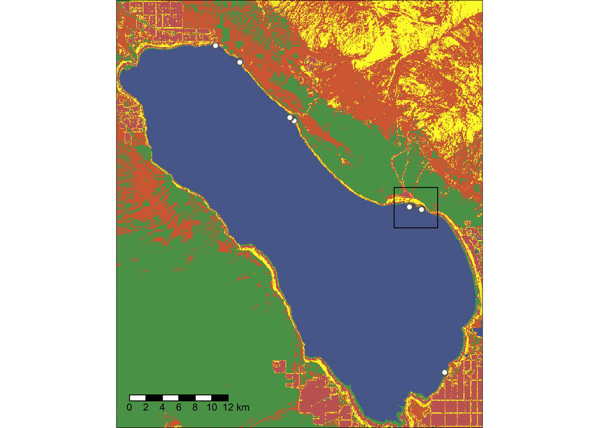

```r
zoomedOut <- tm_shape(rasterSa)+
  tm_raster(palette = 'Set1', legend.show = FALSE)+
  tm_shape(siteSf)+
  tm_dots(size = 0.2, col = 'white', shape = 21)+
  tm_scale_bar(text.size = 0.7, position = 'left')+
  tm_shape(bbAreaBig)+
  tm_borders(col = 'black')+
  tm_layout(outer.margins = c(0, 0, 0, 0), inner.margins = c(0, 0, 0, 0))

zoomedOut
```

Plot 3 zooms in on the Bombay Beach site to show the sampling points at three separate visits.

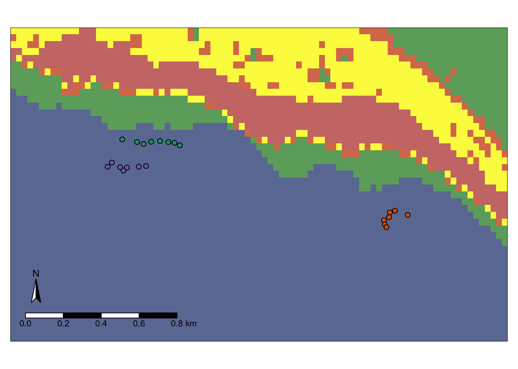

```r
zoomedIn <- tm_shape(rasterBb)+
  tm_raster(palette = 'Set1', alpha = 0.9, legend.show = FALSE)+
  tm_shape(bbSf)+
  tm_dots(shape = 21,
          size = 0.2,
          border.col = 1,
          col = 'Month',
          title = 'Sample Date',
          palette = 'Dark2',
          legend.show = FALSE)+
  tm_compass(position = 'left')+
  tm_scale_bar(text.size = 0.7, position = 'left')

zoomedIn
```

The legend for the zoomed-in plot:

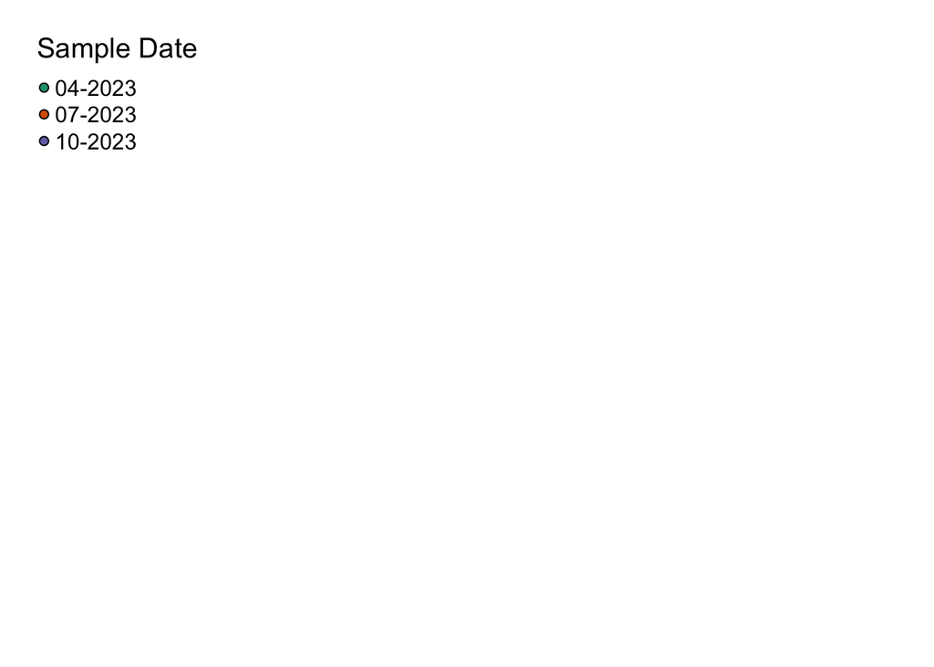

```r
legend <- tm_shape(bbSf)+
  tm_dots(shape = 21,
          size = 0.2,
          border.col = 1,
          col = 'Month',
          title = 'Sample Date',
          palette = 'Dark2')+
  tm_legend(text.size = 1, title.size = 1.5)+
  tm_layout(legend.only = TRUE,
            title.position = c('center', 'center'))

legend
```

All plots in single panel:

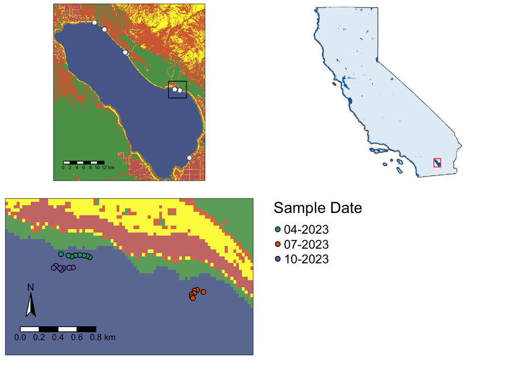

```r
tmap_arrange(zoomedOut, Cali, zoomedIn, legend, ncol = 2, asp = NA)
```